# Parameters of Probability Distributions

TEMBA Statistics 2026

## What payoff should the lender expect?

We use the small-business loan and round its historical default rate to 0.25. The $10,000 loan charges 12% interest and recovers 60% of principal after default.

| Outcome | Probability |
| --- | --- |
| Repaid: $11,200 | 0.75 |
| Default: $6,000 | 0.25 |

## The mean of a random variable

**Definition: Mean (expected value) of a random variable**

The mean is a weighted average of the possible outcomes, with each outcome weighted by its probability:

$$E[X] = \sum_{i=1}^{k} \Pr(X = x_i)\,x_i$$

We often write $\mu$: $E[X] = \mu$.

The expected value is the long-run average outcome when the random process repeats many times. For a fair coin coded $X = 1$ for heads and $X = 0$ for tails, $E[X] = 0.5$. If you flip long enough, the average of your 0s and 1s will get arbitrarily close to 0.5.

## The expected payoff at 12%

| Outcome | Probability | Probability × outcome |
| --- | --- | --- |
| Repaid: $11,200 | 0.75 | $8,400 |
| Default: $6,000 | 0.25 | $1,500 |
| **Expected value** |  | $9,900 |

Subtracting the $10,000 principal gives an expected profit of -$100: at 12% interest, this loan *loses* $100 on average.

## Raising the rate to 16%

| Outcome | Probability | Probability × outcome |
| --- | --- | --- |
| Repaid: $11,600 | 0.75 | $8,700 |
| Default: $6,000 | 0.25 | $1,500 |
| **Expected value** |  | $10,200 |

At 16% interest, the expected profit is $200 per loan. The loan is now profitable on average.

## Example: the expected Fed rate

The [CME FedWatch](https://www.cmegroup.com/markets/interest-rates/cme-fedwatch-tool.html) model assigns probabilities to target ranges after each meeting.

**July 29 meeting**

| Target range | Midpoint | Probability |
| --- | --- | --- |
| 3.50–3.75% | 3.625% | 0.759 |
| 3.75–4.00% | 3.875% | 0.241 |

**September 16 meeting**

| Target range | Midpoint | Probability |
| --- | --- | --- |
| 3.50–3.75% | 3.625% | 0.366 |
| 3.75–4.00% | 3.875% | 0.509 |
| 4.00–4.25% | 4.125% | 0.125 |

Weighting midpoints by probabilities gives an implied expected target rate of 3.685% after July and 3.815% after September. Neither is a possible outcome — the range moves in quarter-point steps.

## Expected warranty cost

The seller’s one-year warranty cost for one appliance has this distribution:

| Cost | Probability |
| --- | --- |
| $0 | 0.82 |
| $120 | 0.15 |
| $600 | 0.03 |

What is the expected cost per appliance? Why is that value useful even if no individual warranty has that cost?

$$E[W]=0.82(0)+0.15(120)+0.03(600)=\$36.$$

An individual warranty costs $0, $120, or $600. Across many appliances, the average warranty cost should land near $36 if the model continues to describe the outcomes.

## Two loans, same expected profit

**Loan A (higher-risk borrower, 14%)**

| Profit | Probability | Probability × profit |
| --- | --- | --- |
| $1,400 | 0.80 | $1,120 |
| -$4,000 | 0.20 | -$800 |
| **Expected profit** |  | $320 |

**Loan B (lower-risk borrower, 8%)**

| Profit | Probability | Probability × profit |
| --- | --- | --- |
| $800 | 0.90 | $720 |
| -$4,000 | 0.10 | -$400 |
| **Expected profit** |  | $320 |

Both loans earn $320 on average. **Which would you rather fund?**

## Variance and standard deviation

**Definition: Variance and standard deviation of a random variable**

The probability-weighted average of squared deviations from the mean:

$$\text{Var}(X) = \sum_{i=1}^{k} \Pr(X = x_i)\,(x_i - \mu)^2$$

We write $\sigma^2 = \text{Var}(X)$. The **standard deviation** $\sigma = \sqrt{\text{Var}(X)}$ is back in the units of $X$.

The variance is the expected squared distance between the random variable and its mean — how wrong we expect to be if we predict $X$ by $\mu$.

## Notation for distributions and samples

| Symbol | Meaning |
| --- | --- |
| $X$ | A random variable whose value is uncertain. |
| $x$ | A possible or realized value of $X$. |
| $\mu$, $\sigma$ | Parameters of a probability distribution. |
| $\bar{x}$, $s$ | Statistics computed from an observed sample. |

Greek letters describe distribution parameters. Latin letters describe values or statistics.

**Quick check:** The observed sample mean is $38 and $\mu=\$36$ in a model for future warranties. Which number is a statistic, and which is a parameter?

## Standard deviation measures risk

The standard deviation of an uncertain payoff measures its unpredictability, or **risk**.

|  | Loan A (higher-risk borrower, 14%) | Loan B (lower-risk borrower, 8%) |
| --- | --- | --- |
| Profit if repaid | $1,400 | $800 |
| Profit if default | -$4,000 | -$4,000 |
| Default probability | 0.20 | 0.10 |
| Expected profit | $320 | $320 |
| Standard deviation | $2,160 | $1,440 |

The standard deviation increases when more probability falls on outcomes far from the expected value. If Loan B were for $100,000 instead of $10,000, its standard deviation would increase tenfold. Its default probability would stay fixed.

## Two stocks with the same expected return

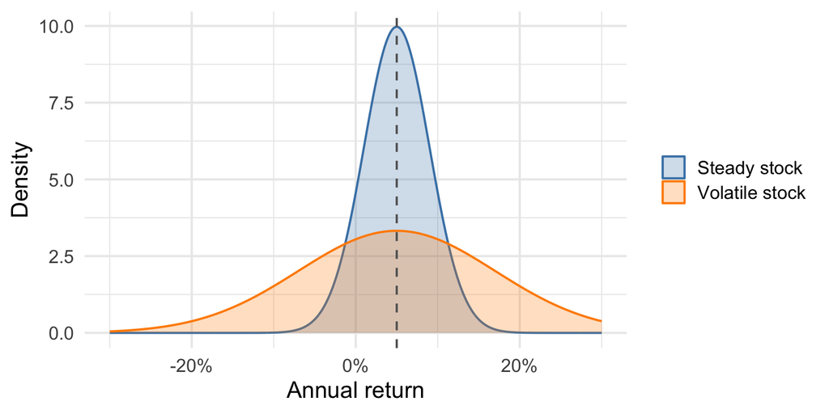

The two stocks have the same expected return, but the volatile stock has a larger standard deviation.

## The median of a random variable

The median splits the probability in half: the smallest value where the cumulative probability reaches 0.50. For the price model, that’s $488,127.

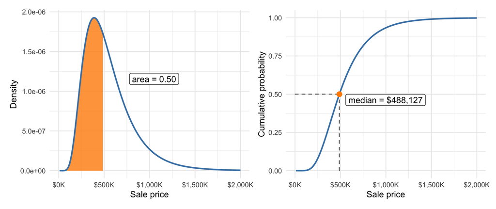

The model’s mean price of $546,458 sits $58,331 above the median, pulled up by the long right tail just as in the observed data.

## Quantiles and the IQR

The $p$-th quantile is the smallest value where cumulative probability reaches $p$.

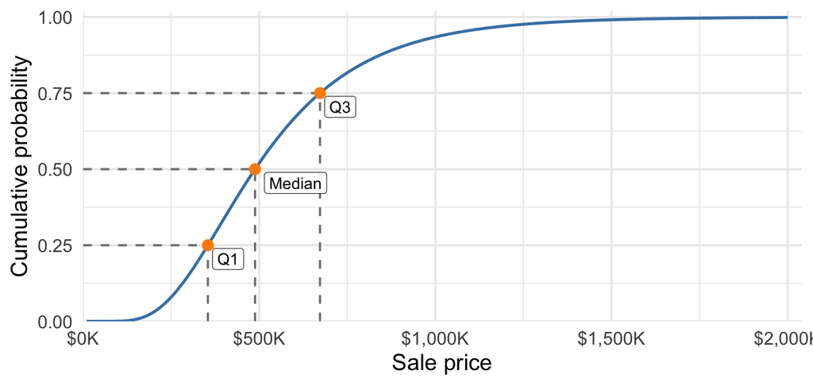

The middle half of future prices runs from $354,282 to $672,536, an IQR of $318,254.

## Quantiles for staffing

A call center models next-hour call volume as follows. Find $Q_1$, the median, $Q_3$, the IQR, and the smallest threshold that covers at least 75% of hours.

| Calls | Probability |
| --- | --- |
| 20 | 0.10 |
| 30 | 0.25 |
| 40 | 0.40 |
| 50 | 0.20 |
| 60 | 0.05 |

| Calls | Probability | Cumulative probability |
| --- | --- | --- |
| 20 | 0.10 | 0.10 |
| 30 | 0.25 | 0.35 |
| 40 | 0.40 | 0.75 |
| 50 | 0.20 | 0.95 |
| 60 | 0.05 | 1.00 |

$Q_1=30$, the median and $Q_3$ are both 40, and the IQR is 10 calls. Staffing for 40 calls covers at least 75% of modeled hours.

## Shifting and scaling

**Mean, median, variance, and standard deviation of $aX + b$**

If $m$ is the median of $X$, then

$$E[aX + b] = a\,\mu + b, \qquad \operatorname{median}(aX+b)=a\,m+b,$$

$$\operatorname{Var}(aX+b)=a^2\sigma^2, \qquad SD(aX + b) = |a|\,\sigma.$$

- Adding a constant shifts the center and leaves the spread alone — shifting can’t make an uncertain payoff more or less predictable.
- Multiplying by a constant scales both the center and the spread.
- A special case is **standardization**: $Z = \frac{X - \mu}{\sigma}$. The standardized random variable has mean 0 and standard deviation 1, and a realized value of $Z$ is a **z-score**.